# Rapport UE4

NGOUO TAPINFO Ulrich Nelson et Christophe LINHARD

4 janvier 2019

## Entrepot de données au format i2b2

Un entrepôt de données, ou data Warehouse, est une vision centralisée et universelle de toutes les informations de l’entreprise. C’est une structure (comme une base de données) qui a pour but, contrairement aux bases de données, de regrouper les données de l’entreprise pour des fins analytiques et pour aider à la décision stratégique. Dans le cadre de notre projet nous avons opté pour le format i2b2 qui représente l’entrepôt de données sous la forme d’une étoile. Cela permet de mettre en relation directe les dimensions (axes avec lesquels on veut faire l’analyse) et les faits (ce sur quoi va porter l’analyse) dans un entrepôt de données. Le format i2b2 a pour avantage d’étre adapté à une recherche multi domaines (surtout pour la santé), est simple, on peut l’utiliser à n’importe quelle échelle et il possède une dimension collaborative. Nous pouvons observer dans la figure ci-dessous la structure de notre entrepôt de données.

```
## [1] "Entrepot de données"
```

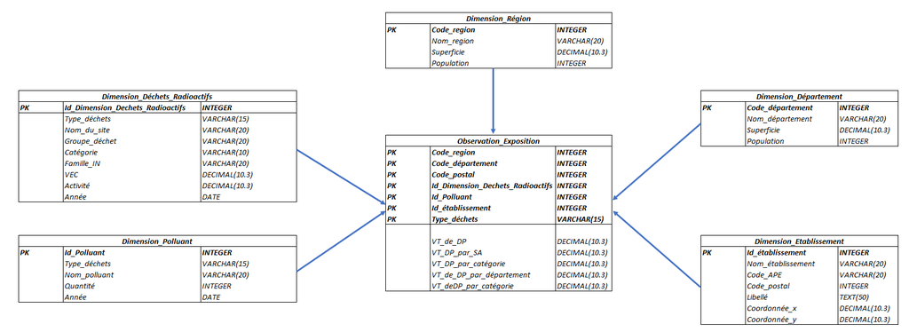

Cet entrepôt de données contient 5 tables de dimensions (Polluants, Radioactifs, Départements, Etablissement, Région) et une table de fait centrale (Observation_Exposition). La dimension “géographique” est représentée dans cet entrepôt de données à travers les tables “Départements”, “Région” et “Etablissement”. Cependant, nous avons choisi de ne pas insérer de tables concernant les communes et villes car elles étaient absentes du fichier de données de maladie “evenement.csv” et donc nous n’aurions pas pu utiliser ces 2 tables pour notre étude statistique. De plus, la quantité d’informations disponible pour ces 2 entités n’était pas suffisante pour construire une table “communes” et une table “villes”. Nous n’avons pas inséré de table “Maladie” car nous avons jugé que ces données changeait trop souvent et qu’il n’était donc pas nécessaire de la faire dans notre entrpét de données. En effet, lorsque l’on fait une étude statistique pour une maladie X et des polluants/déchets radioactifs, les données concernant les polluants ou les déchets radioactifs ne changent pratiquement pas (update tous les ans) alors que celui concernant la maladie change assez souvent et est spécifique de la maladie étudiée. Pour pouvoir différencier le type de déchets obtenus à l’aide de la table de fait nous lui avons mit comme attribut “Type_Dechet” qui prend comme valeur “Radioactif” ou “Polluant” et permet donc de spécifier l’origine du déchet.

## Cartes interactives : Shiny & Leaflet

```
## [1] "carte interactive des départements français"
```

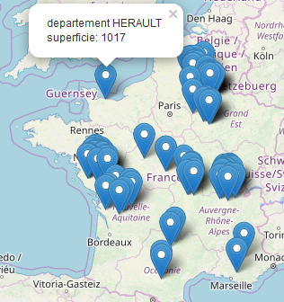

```
## [1] "carte interactive de la quantité de polluants par départements"
```

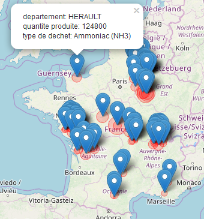

## Statistiques Spatiales

### Choix et préparation des données

Pour pouvoir faire les statistiques spatiales concernant la maladie X, deux des 4 sources proposées ont été prises : les déchets radioactifs et les polluants. Ces 2 sources nous ont permis d’obtenir 2 fichier csv contenant les données au niveau départemental voir communal. Cependant, le fichier de données de la maladie X ne permettait de travailler que jusqu’au niveau départemental. Nous avons donc fait une analyse au niveau départemental de la relation entre la maladie X et les déchets radioactifs ou les polluants. De plus, il a fallu obtenir la carte des départements franéais pour un affichage sous R et cela nous a contraint à regrouper par départements les données contenues dans les fichiers pour la maladie X, les déchets radioactifs et les polluants tout en reformattant leur nom afin qu’ils correspondent à ceux sur la carte de france récupérées (suppression des accents, nom en majuscule…). Puis nous avons crée deux data frame contenant les données d’intérét pour effectuer les statistiques spatiales : une pour la maladie X plus les déchets radioactifs et une pour la maladie X plus les polluants.

```
## [1] "Maladie X en fonction des déchets radioactifs"
```

```
##  Departements          Malades         Quantite             expect
##  Length:78          Min.   : 0.00   Min.   :3.000e+04   Min.   :   0.000
##  Class :character   1st Qu.: 7.00   1st Qu.:2.848e+10   1st Qu.:   0.000
##  Mode  :character   Median :13.00   Median :6.201e+12   Median :   0.000
##                     Mean   :16.32   Mean   :2.627e+18   Mean   :  16.320
##                     3rd Qu.:21.00   3rd Qu.:1.239e+16   3rd Qu.:   0.077
##                     Max.   :80.00   Max.   :1.792e+20   Max.   :1113.483
##       SMR
##  Min.   :0.000e+00
##  1st Qu.:8.400e+01
##  Median :2.420e+05
##  Mean   :4.579e+11
##  3rd Qu.:3.389e+07
##  Max.   :3.219e+13
```

```
## [1] "Maladie X en fonction des polluants"
```

```
##  Departements          Malades         Quantite
##  Length:96          Min.   : 0.00   Min.   :6.986e+05
##  Class :character   1st Qu.: 7.00   1st Qu.:5.655e+07
##  Mode  :character   Median :12.00   Median :1.194e+08
##                     Mean   :14.69   Mean   :4.609e+08
##                     3rd Qu.:19.00   3rd Qu.:2.477e+08
##                     Max.   :80.00   Max.   :8.606e+09
##      expect               SMR
##  Min.   :  0.02226   Min.   :  0.000
##  1st Qu.:  1.80203   1st Qu.:  1.087
##  Median :  3.80387   Median :  2.965
##  Mean   : 14.68750   Mean   :  6.826
##  3rd Qu.:  7.89454   3rd Qu.:  5.559
##  Max.   :274.24671   Max.   :179.674
```

### Cartographie de la maladie X en fonction des déchets radioactifs ou des polluants

Suite à cela nous avons commencé par représenté sur la carte le nombre de malade en fonction du nombre de déchets radioactifs (2ème graphe) ou de polluants (1er graphe) avant de faire la méthode de concentration.

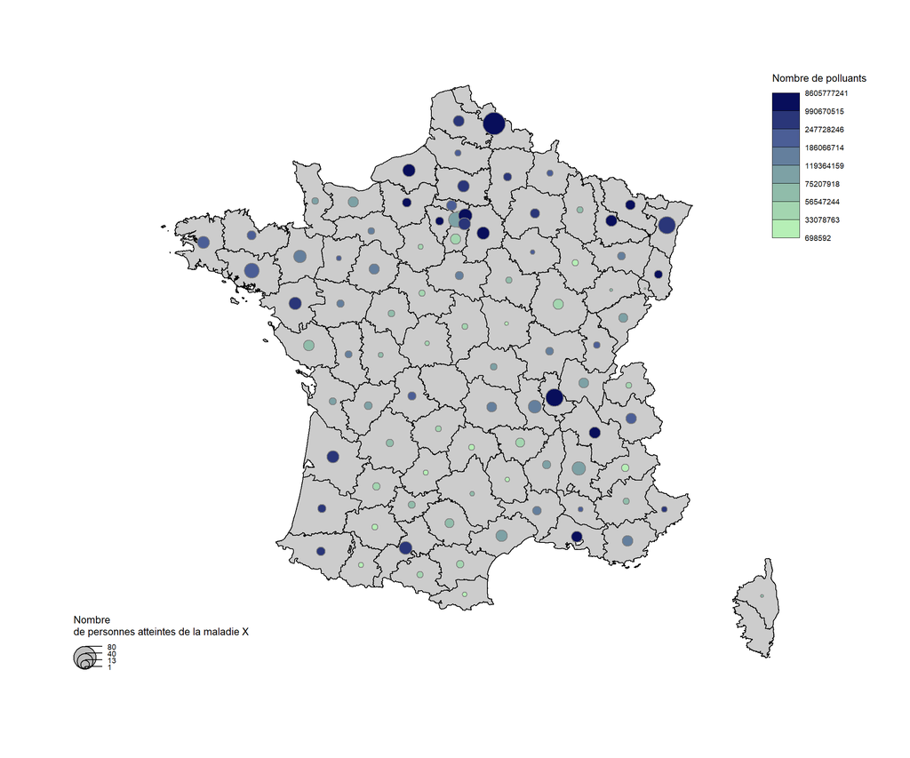

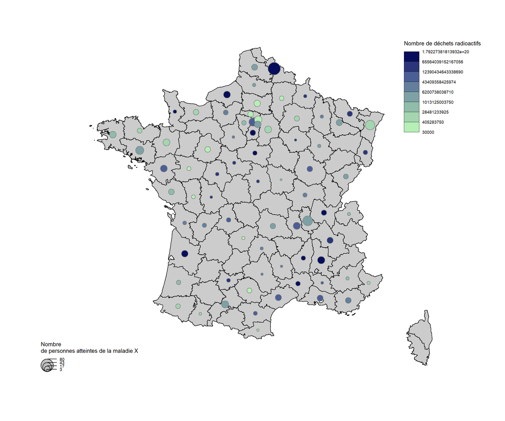

Comme nous pouvons le voir sur ces 2 graphiques, il semble qu’il n’y ait pas de relation entre la quantité de polluants ou de déchets radioactifs et de personnes ayant la maladie X.

### Méthode de concentration : Test de Stone

Le test de Stone permet de donner le nombre de zones (ici, de départements) ayant le risque accumulé maximum et donc, dans notre cas, le nombre de départements ayant le plus haut taux de chances d’avoir des malades atteint de X. Pour pouvoir faire ce test statistique il faut d’abord obtenir à partir de nos données, la zone présentant le plus de risque et donc il faut représenter sur la carte les zones en fonction de leur risque d’avoir des personnes atteintes de la maladie X. Nous avons donc effectué une standardisation des données pour chacune des 2 relations testées (Maladie X et déchets radioactifs ET Maladie X et polluants) dont nous pouvons voir un exemple de résultats ci-dessous.

```
## Object of class SpatialPolygonsDataFrame
## Coordinates:
##         min     max
## x   99217.1 1242417
## y 6049646.3 7110480
## Is projected: TRUE
## proj4string :
## [+proj=lcc +lat_1=44 +lat_2=49 +lat_0=46.5 +lon_0=3 +x_0=700000
## +y_0=6600000 +ellps=GRS80 +units=m +no_defs]
## Data attributes:
##                     ID_GEOFLA    CODE_DEPT                     NOM_DEPT
##  DEPARTEM0000000000000001: 1   01     : 1   AIN                    : 1
##  DEPARTEM0000000000000002: 1   02     : 1   AISNE                  : 1
##  DEPARTEM0000000000000003: 1   03     : 1   ALLIER                 : 1
##  DEPARTEM0000000000000004: 1   04     : 1   ALPES-DE-HAUTE-PROVENCE: 1
##  DEPARTEM0000000000000005: 1   05     : 1   ALPES-MARITIMES        : 1
##  DEPARTEM0000000000000006: 1   06     : 1   ARDECHE                : 1
##  (Other)                 :90   (Other):90   (Other)                :90
##     CODE_CHF     NOM_CHF     X_CHF_LIEU        Y_CHF_LIEU
##  001    : 2   AGEN   : 1   Min.   : 171326   Min.   :6108968
##  004    : 2   AJACCIO: 1   1st Qu.: 553177   1st Qu.:6401238
##  007    : 2   ALBI   : 1   Median : 658409   Median :6631771
##  010    : 2   ALENCON: 1   Mean   : 684049   Mean   :6609885
##  033    : 2   AMIENS : 1   3rd Qu.: 846156   3rd Qu.:6820420
##  085    : 2   ANGERS : 1   Max.   :1228512   Max.   :7059443
##  (Other):84   (Other):90
##    X_CENTROID        Y_CENTROID         CODE_REG
##  Min.   : 115669   Min.   :6050394   76     :13
##  1st Qu.: 544294   1st Qu.:6398674   75     :12
##  Median : 659892   Median :6639324   84     :12
##  Mean   : 681127   Mean   :6611276   44     :10
##  3rd Qu.: 838334   3rd Qu.:6834668   11     : 8
##  Max.   :1225168   Max.   :7046488   27     : 8
##                                      (Other):33
##                                 NOM_REG        SMR
##  LANGUEDOC-ROUSSILLON-MIDI-PYRENEES :13   Min.   :0.00000
##  AQUITAINE-LIMOUSIN-POITOU-CHARENTES:12   1st Qu.:0.04841
##  AUVERGNE-RHONE-ALPES               :12   Median :0.13203
##  ALSACE-CHAMPAGNE-ARDENNE-LORRAINE  :10   Mean   :0.30394
##  BOURGOGNE-FRANCHE-COMTE            : 8   3rd Qu.:0.24752
##  ILE-DE-FRANCE                      : 8   Max.   :8.00000
##  (Other)                            :33
```

Puis nous avons obtenus les résultats ci-dessous pour la carte de france (polluants 1er graphe et déchets radioactifs 2ème graphe).

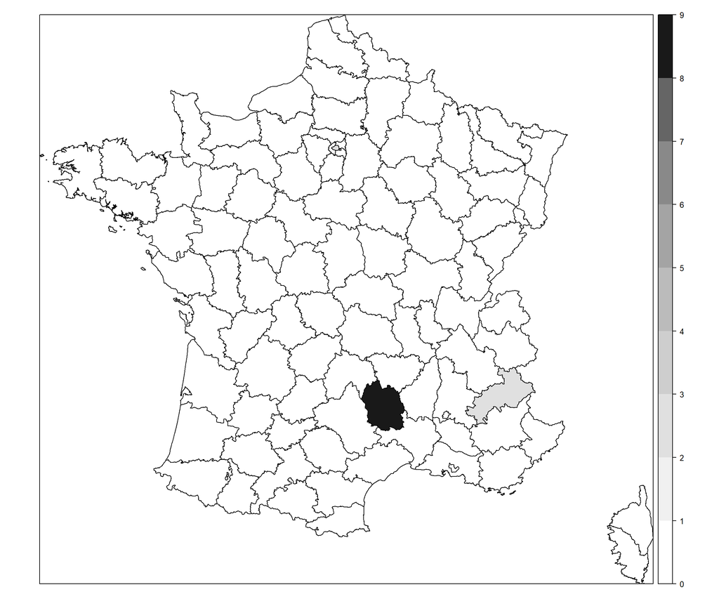

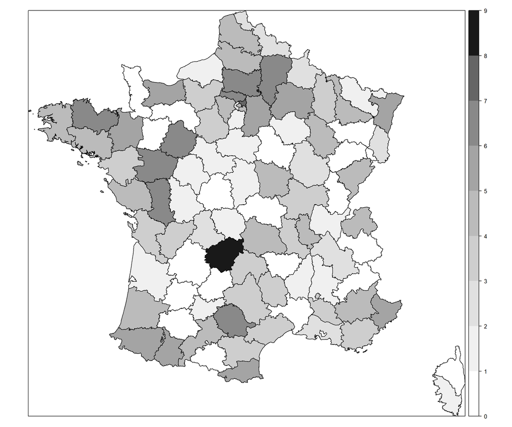

Il est important de noter que comparer aux résultats pour les déchets radioactifs, sur la carte on a pas ou peu de zones présentant un risque pour la maladie X en fonction des polluants. Ceci est faux et est dé au fait qu’il y a certaines régions possédant d’énorme quantité de polluants comparé aux autres et donc, comme nous avons normalisées les données à représenter, la plupart des valeurs sont proches de 0 car la différence entre ces valeurs et la valeur maximale est trés importante. A partir des résultats de ces 2 cartographies nous avons identifié comme zone à plus haut risque la Lozére pour les polluants et la Corréze pour les déchets radioactifs et nous avons donc utilisé ces régions pour le test de stone dont les résultats sont visibles ci-dessous.

```
## [1] "Maladie X en fonction des polluants"
```

```
##              region
##  3.158416 43.000000
```

```
## Stone's Test for raised incidence around locations
##
##  Type of boots.: parametric
##  Model used when sampling: Poisson
##  Number of simulations: 99
##  Statistic:  3.158416
##  p-value :  0.01
```

```
## [1] "Maladie X en fonction des déchets radioactifs"
```

```
##            region
## 110.5499  10.0000
```

```
## Stone's Test for raised incidence around locations
##
##  Type of boots.: parametric
##  Model used when sampling: Poisson
##  Number of simulations: 99
##  Statistic:  110.5499
##  p-value :  0.01
```

### Méthode de concentration : Test de Moran

Le test de Moran sert à vérifier si il y a une autocorrélation spatiale, l’hypothése nulle étant qu’il n’y a pas d’autocorrélation spatiale. Pour faire ce test sous R il nous faut la matrice des voisins avec leur poids ainsi qu’une matrice au format spécifié par DCluster (Observé, Attendu). Nous avons donc commencé par récupérer la matrice des voisins avec leur poids à l’aide des fonction poly2nb et nb2listw. La fonction poly2nb permet d’obtenir les voisins et leur poids à partir d’une carte (ou format SpatialPolygonsDataFrame) et la fonction nb2listw permet de transformer le résultat obtenu à l’aide de poly2nb en une liste au format “W” qui est nécessaire pour la fonction de Moran utilisée par le package DCluster. Nous pouvons observer cette liste ci-dessous

```
## Characteristics of weights list object:
## Neighbour list object:
## Number of regions: 96
## Number of nonzero links: 476
## Percentage nonzero weights: 5.164931
## Average number of links: 4.958333
## Link number distribution:
##
##  1  2  3  4  5  6  7  8 10
##  2  6 12 14 19 30 11  1  1
## 2 least connected regions:
## 46 78 with 1 link
## 1 most connected region:
## 51 with 10 links
##
## Weights style: W
## Weights constants summary:
##    n   nn S0       S1       S2
## W 96 9216 96 44.29206 391.9874
```

Puis nous avons créer les 2 data frame au format DCluster pour finalement faire le test de Moran sur chacune des 2 matrices. Nous pouvons voir les résultats ci-dessous.

```
## [1] "Maladie X en fonction des polluants"
```

```
## [1] -0.03992004
```

```
## [1] -0.0352037
```

```
## Moran's I test of spatial autocorrelation
##
##  Type of boots.: parametric
##  Model used when sampling: Poisson
##  Number of simulations: 99
##  Statistic:  -0.03992004
##  p-value :  0.44
```

```
## [1] "Maladie X en fonction des déchets radioactifs"
```

```
## [1] -0.01247501
```

```
## [1] -0.005580301
```

```
## Moran's I test of spatial autocorrelation
##
##  Type of boots.: parametric
##  Model used when sampling: Poisson
##  Number of simulations: 99
##  Statistic:  -0.01247501
##  p-value :  0.91
```

Que ce soit pour les polluants ou les déchets radioactifs les valeurs étant négatives il n’y a pas d’autocorrélation spatiale.